# Figures

John Favate

2023-01-24 10:19:48

```r
# Prevent printing of warnings and such in the HTML
knitr::opts_chunk$set(warning = FALSE, message = FALSE, fig.align = "center")
```

```r
library(tidyverse)
library(ggpubr)
library(scales)
library(ggpointdensity)
library(patchwork)
library(broom)

futile.logger::flog.threshold(futile.logger::ERROR, name = "VennDiagramLogger")
```

```r
kdf <- read_csv("../data_frames/kallisto_results.csv")

# DEseq results
dsdf <- read_csv("../data_frames/deseq_results.csv")
```

### RNAseq TPM compared to DESeq fold change in condition / RNAseq

cutoffs

```r
qcut <- .01
fccut <- 1
```

The global text size

```r
ts <- 16
```

The average RNAseq TPMs

```r
rna.samples <- c(
  paste0("WT-", 1:3),
  paste0("Xrn1-H41A-", 1:3)
)

# mean TPMs from these samples
mean.tpms <- kdf %>%
  filter(sample %in% rna.samples) %>%
  mutate(sample = str_remove(sample, "-\\d{1}")) %>%
  group_by(sample, target_id) %>%
  summarise(mean_tpm = mean(tpm)) %>%
  split(.$sample)
```

Get the fold changes and padj values

```r
fc.list <- list(
  "SPAAC seq (WT)" = "wt_spaac_over_wt_rnaseq",
  "D-SPAAC seq (WT)" = "wt_dspaac_over_wt_rnaseq",
  "SPAAC seq (xrn1 H41A)" = "mut_spaac_over_mut_rnaseq",
  "D-SPAAC seq (xrn1 H41A)" = "mut_dspaac_over_mut_rnaseq"
)

fc.plot.df <- sapply(names(fc.list), function(x) {
  fc.df <- dsdf %>%
    filter(comparison == fc.list[[x]]) %>%
    select(target_id, sgd, gene_name, log2FoldChange, padj) %>%
    mutate(
      sig = ifelse(log2FoldChange >= fccut & padj <= qcut, TRUE, FALSE),
      sig = ifelse(is.na(sig), FALSE, sig)
    )

  # pick the correct rnaseq data
  if (grepl("WT", x)){
    joined.df <- left_join(fc.df, mean.tpms$WT)
  } else {
    joined.df <- left_join(fc.df, mean.tpms$`Xrn1-H41A`)
  }
}, simplify = FALSE) %>%
  bind_rows(.id = "comp")
```

Make it so that significant genes in one genotype are blue (and shades of blue to show DSPAAC/SPAAC), and the other genotype is shades of red. circ genes are Imd4 = S000004520, sgf11 = S000005968, enb1 = SGD:S000005518

```r
match.df <- data.frame(
  genotype = c("wt", "wt", "mut", "mut"),
  seqtype = c("dspaac", "spaac", "dspaac", "spaac"),
  code = c("a", "b", "c", "d")
)

# genes to be labeled
lab.genes <- c("S000004520", "S000005968", "S000005518")

fc.plot.df2 <- fc.plot.df %>%
  mutate(genotype = ifelse(grepl("WT", comp), "wt", "mut"),
         seqtype = ifelse(grepl("D-SPAAC", comp), "dspaac", "spaac")) %>%
  left_join(match.df) %>%
  mutate(sig2 = ifelse(sig == TRUE, code, "z"), # if it's not sig point, it'll be grey
         comp = factor(comp, levels = names(fc.list)), # the facets are to be in this order
         labz = ifelse(sgd %in% lab.genes, gene_name, NA), # if it's a special gene, it's got a label
         sig2 = ifelse(is.na(labz), sig2, "0"),# if it has a label, it's a different color
         sig2 = ifelse(mean_tpm == 0 & log2FoldChange >= 1 & padj <=.01, "x", sig2)) # if its a gene with no counts but FC >= 1 and q<= .01.
```

Find the number of significant genes in each

```r
nsigs <- fc.plot.df2 %>%
  filter(sig == TRUE) %>%
  group_by(comp) %>%
  tally() %>%
  mutate(code = c("b", "a", "d", "c"))
```

Get the 7 colors, two for each genotype, one for not sig, one for labeled genes

```r
colorz <- c("black", "#A6CEE3", "#1F78B4", "#FDBF6F", "#FF7F00", "red", "grey70")
```

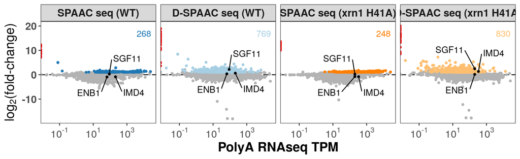

```r
fc.plots <- fc.plot.df2 %>%
  arrange(desc(sig2)) %>%
  ggplot(., aes(mean_tpm, log2FoldChange, color = sig2, label = labz)) +
  geom_hline(aes(yintercept = 0), linetype = 5) +
  geom_point(size = 1) +
  ggrepel::geom_text_repel(box.padding = 1)+
  geom_text(inherit.aes = FALSE, data = nsigs, aes(x = 1e4, 17, label = n, color = code))+
  scale_x_log10(labels = trans_format("log10", math_format(10 ^ .x))) +
  theme_bw() +
  theme(panel.grid = element_blank(),
        text = element_text(size = ts, face = "bold")) +
  facet_wrap( ~ comp, ncol = 4)+
  labs(x = "PolyA RNAseq TPM",
       y = expression(paste(log[2], "(fold-change)")))+
  scale_color_manual(values = colorz, guide = "none")

ggsave(plot = fc.plots, filename = "../figures/l2fc_vs_rnaseq_tpm.png", width = 9, height = 2.75)

fc.plots
```

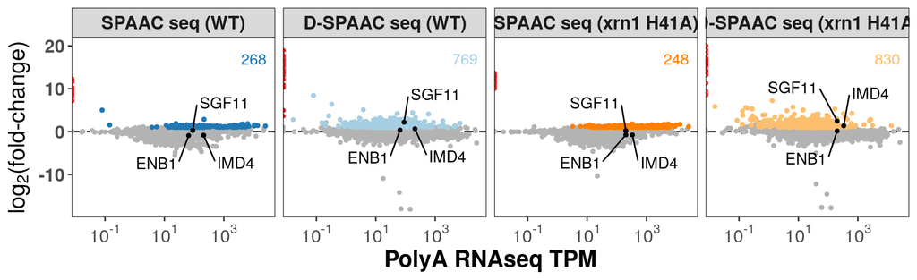

```r
fc.plots2 <- fc.plot.df2 %>%
  arrange(desc(sig2)) %>%
  ggplot(., aes(mean_tpm, log2FoldChange, color = sig2, label = labz)) +
  geom_hline(aes(yintercept = 0), linetype = 5) +
  geom_point(size = 1) +
  ggrepel::geom_text_repel(box.padding = 1)+
  geom_text(inherit.aes = FALSE, data = nsigs, aes(x = 1e4, 4, label = n, color = code))+
  scale_x_log10(labels = trans_format("log10", math_format(10 ^ .x))) +
  theme_bw() +
  theme(panel.grid = element_blank(),
        text = element_text(size = ts, face = "bold")) +
  facet_wrap( ~ comp, ncol = 4)+
  labs(x = "PolyA RNAseq TPM",
       y = expression(paste(log[2], "(fold-change)")))+
  scale_color_manual(values = colorz, guide = "none")+
  coord_cartesian(ylim = c(-5, 5))

ggsave(plot = fc.plots2, filename = "../figures/l2fc_vs_rnaseq_tpm2.png", width = 9, height = 2.75)

fc.plots
```

Only issue with this plot is that as it’s labeled now, you need to read the caption to know what the FC is between.

The values for the specific genes

```r
fc.plot.df2 %>%
  filter(sgd %in% lab.genes) %>%
  arrange(sgd, sample)
```

| comp | target_id | sgd | gene_name | log2FoldChange | padj | sig | sample | mean_tpm | genotype | seqtype | code | sig2 | labz |
| --- | --- | --- | --- | --- | --- | --- | --- | --- | --- | --- | --- | --- | --- |
| SPAAC seq (WT) | NM_001182414.1 | S000004520 | IMD4 | -0.8499349 | 8.187307e-183 | FALSE | WT | 209.10702 | wt | spaac | b | 0 | IMD4 |
| D-SPAAC seq (WT) | NM_001182414.1 | S000004520 | IMD4 | 0.6564483 | 1.032479e-110 | FALSE | WT | 209.10702 | wt | dspaac | a | 0 | IMD4 |
| SPAAC seq (xrn1 H41A) | NM_001182414.1 | S000004520 | IMD4 | -0.7792832 | 1.702601e-122 | FALSE | Xrn1-H41A | 334.64164 | mut | spaac | d | 0 | IMD4 |
| D-SPAAC seq (xrn1 H41A) | NM_001182414.1 | S000004520 | IMD4 | 1.3547321 | 0.000000e+00 | TRUE | Xrn1-H41A | 334.64164 | mut | dspaac | c | 0 | IMD4 |
| SPAAC seq (WT) | NM_001183411.1 | S000005518 | ENB1 | -0.9152920 | 5.511063e-119 | FALSE | WT | 65.39069 | wt | spaac | b | 0 | ENB1 |
| D-SPAAC seq (WT) | NM_001183411.1 | S000005518 | ENB1 | 0.3736736 | 3.854722e-25 | FALSE | WT | 65.39069 | wt | dspaac | a | 0 | ENB1 |
| SPAAC seq (xrn1 H41A) | NM_001183411.1 | S000005518 | ENB1 | -0.7508896 | 2.228084e-82 | FALSE | Xrn1-H41A | 201.09383 | mut | spaac | d | 0 | ENB1 |
| D-SPAAC seq (xrn1 H41A) | NM_001183411.1 | S000005518 | ENB1 | 0.1544766 | 8.339943e-06 | FALSE | Xrn1-H41A | 201.09383 | mut | dspaac | c | 0 | ENB1 |
| SPAAC seq (WT) | NM_001183861.1 | S000005968 | SGF11 | 0.2696550 | 7.082526e-04 | FALSE | WT | 89.70106 | wt | spaac | b | 0 | SGF11 |
| D-SPAAC seq (WT) | NM_001183861.1 | S000005968 | SGF11 | 2.1811324 | 3.279818e-286 | TRUE | WT | 89.70106 | wt | dspaac | a | 0 | SGF11 |

[output cut: 2 more lines]

List of genes that are on the y axis, make these into a list per cat

```r
axis.genes <- fc.plot.df %>%
  filter(mean_tpm == 0 & padj <= .01 & log2FoldChange > 1) %>%
  split(.$comp) %>%
  map(.f = pull, target_id)

lapply(names(axis.genes), function(x){
  fixed.name <- x %>%
    str_replace(" / ", "_over_") %>%
    str_replace_all(" ", "_") %>%
    str_remove("\\(") %>%
    str_remove("\\)")

  fname <- paste0("../data_frames/no_rna_detect_but_is_capped_genes_", fixed.name, ".txt")

  write_lines(axis.genes[[x]], fname)
})
```

```
## [[1]]
##  [1] "NM_001178214.1" "NM_001178710.1" "NM_001180049.1" "NM_001180055.1"
##  [5] "NM_001181684.3" "NM_001182398.1" "NM_001182548.1" "NM_001184378.1"
##  [9] "NM_001184385.3" "NM_001184387.1" "NM_001184389.1" "NM_001184393.1"
## [13] "NM_001184395.1" "NM_001184397.1" "NM_001184399.1" "NM_001184401.1"
## [17] "NM_001184407.1" "NM_001184410.1" "NM_001184412.1" "NM_001184413.3"
## [21] "NM_001184414.1" "NM_001184416.1" "NM_001184418.1" "NM_001184422.3"
## [25] "NM_001184424.1" "NM_001184429.1" "NM_001184430.1" "NM_001184431.1"
## [29] "NM_001184433.1" "NM_001184435.3" "NM_001184437.3" "NM_001184514.1"
## [33] "NM_001184682.1" "NM_001348816.1" "NR_132208.1"    "NR_132217.1"
##
## [[2]]
##  [1] "NM_001178214.1" "NM_001178709.1" "NM_001178711.1" "NM_001180047.1"
##  [5] "NM_001180049.1" "NM_001180055.1" "NM_001181684.3" "NM_001182398.1"
##  [9] "NM_001182543.1" "NM_001182548.1" "NM_001184378.1" "NM_001184383.1"
```

[output cut: 21 more lines]

### Comparison to controls

DSPAAC control means

```r
dspaac.control.means <- kdf %>%
  filter(sample %in% c("minusADPRC-1", "minusADPRC-2")) %>%
  group_by(target_id) %>%
  summarise(ctrl = mean(tpm)) %>%
  ungroup()
```

These are all of the samples to be comapred to the controls.

```r
exp.samps <- c(
  paste0("WT-DSPAAC-", 1:3),
  paste0("Xrn1-H41A-DSPAAC-", 1:3),
  paste0("WT-SPAAC-", 1:3),
  paste0("Xrn1-H41A-SPAAC-", 1:3)
)
```

These are the mean TPMs for those samples

```r
experiments.means <- kdf %>%
  filter(sample %in% exp.samps) %>%
  mutate(sample = str_remove(sample, "-\\d{1}")) %>%
  group_by(sample, target_id) %>%
  summarise(exper = mean(tpm)) %>%
  ungroup()
```

This makes the plots that are to be arranged in a 2x2 grid

```r
# join the control and experiment mean TPMs
p.list <- left_join(experiments.means, dspaac.control.means, by = "target_id") %>%
  # for each sample
  split(.$sample) %>%
  map(function(x) {
    # y axis label
    ylabz <- paste(unique(x$sample), "TPM")

    # the scatterplot
    sp <- ggplot(x, aes(ctrl, exper)) +
      geom_pointdensity(size = .5) +
      scale_x_log10(labels = trans_format("log10", math_format(10 ^ .x)),
                    limits = c(1e-2, 1e6)) +
      scale_y_log10(labels = trans_format("log10", math_format(10 ^ .x)),
                    limits = c(1e-3, 1e5)) +
      stat_cor(aes(label = ..r.label..)) +
      geom_abline(aes(slope = 1, intercept = 0), linetype = 5) +
      theme_bw() +
      theme(panel.grid = element_blank(),
            text = element_text(size = ts)) +
      labs(x = "minus ADPRC TPM",
           y = ylabz) +
      scale_color_gradientn(colors = viridis::mako(128), guide = "none")

    # density plot of ratios
    dp.df <- x %>%
      mutate(l2rat = log2(exper / ctrl))

    # figure out % of points above/below line
    percs <- dp.df %>%
      mutate(test = l2rat > 0) %>%
      group_by(test) %>%
      tally() %>%
      filter(!is.na(test)) %>%
      pivot_wider(names_from = test, values_from = n) %>%
      mutate(below.perc = paste0(round((`FALSE` / (`FALSE` + `TRUE`))*100), "%"),
             above.perc = paste0(round((`TRUE` / (`FALSE` + `TRUE`))*100), "%"))

    # % points above/below y=x line
    bp <- percs$below.perc

    ap <- percs$above.perc

    # the density plot
    dp <- dp.df %>%
      ggplot(., aes(l2rat)) +
      geom_density() +
      geom_vline(aes(xintercept = 0), linetype = 5) +
      theme_bw() +
      theme(panel.grid = element_blank(),
            plot.background = element_blank(),
            axis.ticks.y = element_blank()) +
      labs(x = NULL,
           y = NULL) +
      scale_y_continuous(labels = NULL, limits = c(0, .4)) +
      scale_x_continuous(limits = c(-10, 10), breaks = c(-5, 0, 5))+
      annotate("text", x = -7, y = .35, label = bp, size = 3)+
      annotate("text", x = 7, y = .35, label = ap, size = 3)

    # final plot
    sp + inset_element(
      dp,
      left = .6,
      bottom = .00001,
      top = .45,
      right = .99
    )
  })
```

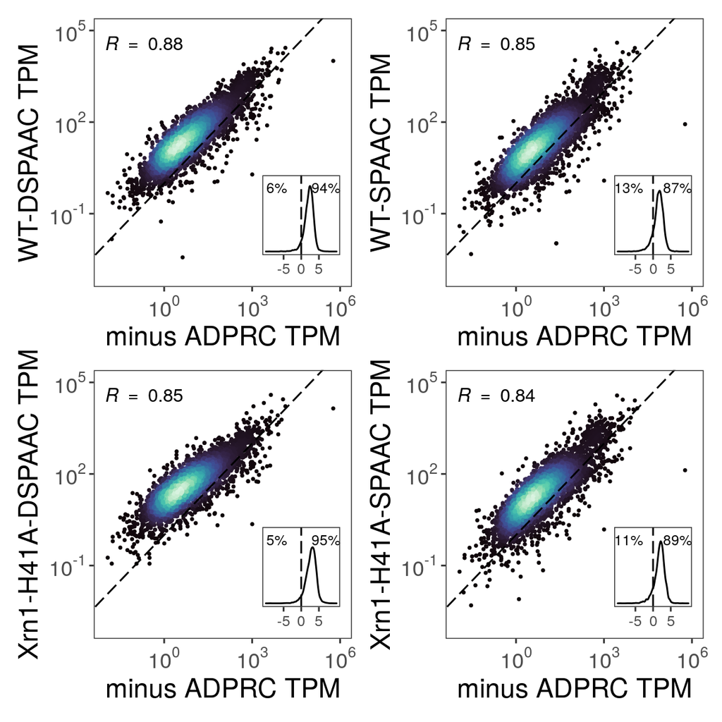

```r
compare.to.controls <- wrap_plots(p.list, ncol = 2)

compare.to.controls
```

```r
ggsave(plot = last_plot(), filename = "../figures/tpm_compare_to_controls.png", width = 6, height = 6)
```

Boxplots and stat comparisons to show those differences, namely that the distribution of ratios for DSPAAC is higher than SPAAC.

```r
rat.df <- left_join(experiments.means, dspaac.control.means, by = "target_id") %>%
  mutate(l2rat = log2(exper / ctrl),
         genotype = ifelse(grepl("Xrn1", sample), "xrn1 H41A", "WT"),
         genotype = factor(genotype, c("WT", "xrn1 H41A")),
         method = ifelse(grepl("DSPAAC", sample), "D-SPAAC", "SPAAC")) %>%
  filter(is.finite(l2rat) & !is.na(l2rat))

comp.list <- list("WT" = c("WT-DSPAAC", "WT-SPAAC"),
                  "xrn1 H41A" = c("Xrn1-H41A-DSPAAC","Xrn1-H41A-SPAAC"))

t.res <- lapply(comp.list, function(x){
  t.test(
    rat.df[rat.df$sample == x[1],]$l2rat,
    rat.df[rat.df$sample == x[2],]$l2rat,
    alternative = "greater"
  ) %>%
    tidy()
}) %>%
  bind_rows()
```

These are not colored because they don’t represent those colored blue/orange genes.

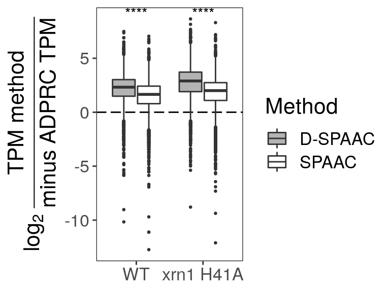

```r
rat.df %>%
  ggplot(., aes(genotype, l2rat, fill = method))+
  geom_hline(aes(yintercept = 0), linetype = 5)+
  geom_boxplot(outlier.size = .5)+
  stat_compare_means(aes(label = ..p.signif..))+
  theme_bw()+
  theme(panel.grid = element_blank(),
        text = element_text(size = ts))+
  labs(x = NULL,
       y = expression(paste(log[2], " ", frac("TPM method", "minus ADPRC TPM"))))+
  scale_fill_manual(values = c("grey70", "white"), name = "Method")
```

```r
ggsave(plot = last_plot(), filename = "../figures/ratio_boxplots.png", width = 4, height = 3)
```

### TPM distributions of SPAAC and DSPAAC

The TPM distribution of the DSPAAC should be lower than the SPAAC because DSPAAC gets the lowly expressed genes whereas SPAAC does not, this much seems obvious from the colored scatterplots.

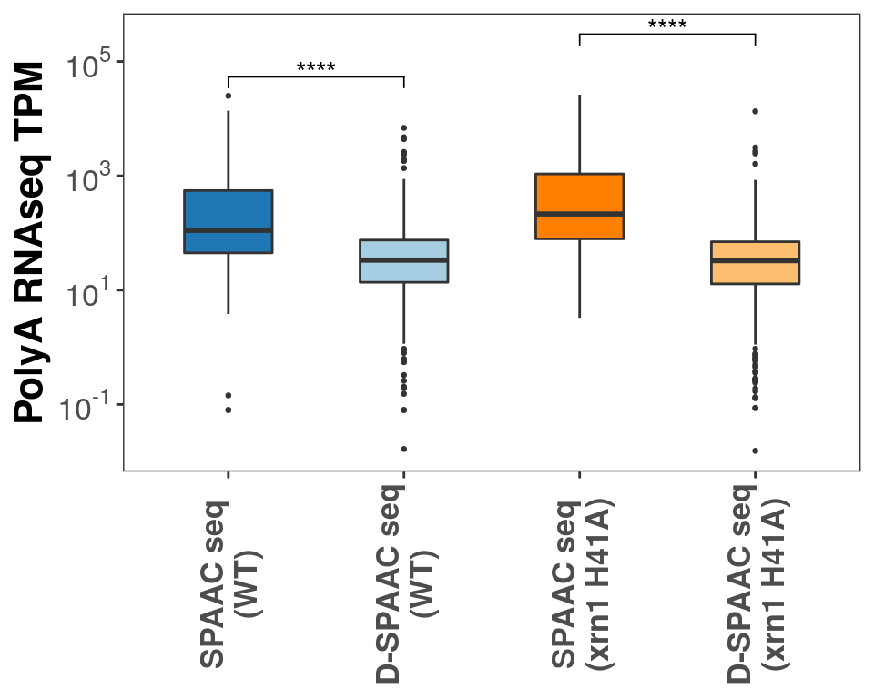

```r
c.list <- list(
  c("D-SPAAC seq (WT)", "SPAAC seq (WT)"),
  c("D-SPAAC seq (xrn1 H41A)", "SPAAC seq (xrn1 H41A)")
)

fc.boxes <- fc.plot.df2 %>%
  filter(sig == TRUE) %>%
  ggplot(., aes(comp, mean_tpm, fill = comp))+
  geom_boxplot(width = .5, outlier.size = .5)+
  scale_y_log10(labels = trans_format("log10", math_format(10 ^ .x)))+
  stat_compare_means(comparisons = c.list, aes(label = ..p.signif..), vjust = .5, method.args = (list("alternative" = "less")))+
  theme_bw()+
  theme(panel.grid = element_blank(),
        text = element_text(size = ts, face = "bold"),
        axis.text.x = element_text(angle = 90, vjust = .5))+
  labs(x = NULL,
       y = "PolyA RNAseq TPM")+
  scale_x_discrete(labels = scales::label_wrap(14))+
  scale_fill_manual(values = c("#1F78B4", "#A6CEE3", "#FF7F00", "#FDBF6F"), guide = "none")

ggsave(plot = fc.boxes, filename = "../figures/tpms_of_sig_genes.png", width = 5, height = 3)

fc.boxes
```

### Venn diagrams

```r
v1 <- VennDiagram::venn.diagram(
  x = fc.plot.df2 %>%
    filter(sig == TRUE & grepl("WT", comp)) %>%
    mutate(comp = str_replace(comp, " seq ", "\nseq ")) %>%
    split(.$comp, drop = TRUE) %>%
    map(.f = pull, target_id),
  filename = '../figures/inc_dspaac_spaac.png',
  output = TRUE,
  scaled = TRUE,
  imagetype = "png" ,
  height = 400 ,
  width = 400 ,
  resolution = 300,
  compression = "lzw",
  cat.pos = c(0, 0),
  cat.dist = c(.05, .05),
  cex = .5,
  cat.cex = .35,
  lwd = .5,
  fill = c("#A6CEE3", "#1F78B4"),
  rotation.degree = 180,
  sub.fontfamily = "Arial"
)

# get the genes as a list
sigs.per.comp <- fc.plot.df %>%
  filter(sig == TRUE) %>%
  split(.$comp) %>%
  map(.f = pull, sgd)

# for the above venn
sigs.per.comp$`D-SPAAC seq (WT)` %>% write_lines("../data_frames/inc_genes_dspaac_spaac.txt")
```

```r
v2 <- VennDiagram::venn.diagram(
  x = fc.plot.df2 %>%
    filter(sig == TRUE &
             comp %in% c("D-SPAAC seq (WT)", "D-SPAAC seq (xrn1 H41A)")) %>%
    mutate(comp = str_replace(comp, " seq ", "\nseq ")) %>%
    split(.$comp, drop = TRUE) %>%
    map(.f = pull, target_id),
  filename = '../figures/inc_wt_mut_dspaac.png',
  output = TRUE,
  scaled = TRUE,
  imagetype = "png" ,
  height = 400 ,
  width = 400 ,
  resolution = 300,
  compression = "lzw",
  cat.pos = c(170, 190),
  cat.dist = c(.05, .05),
  cex = .5,
  cat.cex = .35,
  lwd = .5,
  fill = c("#A6CEE3", "#FDBF6F"),
  rotation.degree = 180,
  sub.fontfamily = "Arial"
)

# genes that are up and unique to mutant
setdiff(
  sigs.per.comp$`D-SPAAC seq (xrn1 H41A)`,
  sigs.per.comp$`D-SPAAC seq (WT)`
) %>%
  write_lines("../data_frames/inc_genes_dspaac_mutant_specific.txt")
```

A reviewer comment requested that we determine how exceptional the overlap between the two sets of genes in the venn diagrams are. We’ll do this by randomly picking x (where is is the number of significant genes in each category) genes from each category and seeing how many overlap and run that a bunch of times.

##### Figure 3c

This is for the figure 3c, which has 63 overlaps

```r
# this is how many genes are significant in each category
f3c.vals <- fc.plot.df2 %>%
    filter(sig == TRUE & grepl("WT", comp)) %>%
    split(.$comp, drop = TRUE) %>%
    map(.f = nrow)

# Essentially asking, if I pick the same number of significant genes from each
# category, how many overlaps do we get compared to how many we actually got?
s3c.rands <- lapply(1:1e4, function(x) {
  # randomly sample a number of genes from D-SPAAC
  ds.genes <- fc.plot.df2 %>%
    filter(comp == "D-SPAAC seq (WT)") %>%
    pull(target_id) %>%
    sample(., size = f3c.vals$`D-SPAAC seq (WT)`, replace = FALSE)

  # randomly sample a number of genes from D-SPAAC
  s.genes <- fc.plot.df2 %>%
    filter(comp == "SPAAC seq (WT)") %>%
    pull(target_id) %>%
    sample(., size = f3c.vals$`SPAAC seq (WT)`, replace = FALSE)

  # calculate overlap
  intersect(ds.genes, s.genes) %>%
    length()
}) %>%
  unlist()
```

A chi squared test will take a contingency table that looks like this

```r
ct <- fc.plot.df2 %>%
  filter(grepl("WT", comp)) %>%
  group_by(sig, comp) %>%
  tally() %>%
  ungroup() %>%
  pivot_wider(names_from = sig, values_from = n) %>%
  column_to_rownames("comp")

c.res1 <- chisq.test(ct) %>%
  broom::tidy() %>%
  mutate(p.value = signif(p.value, 1),
         statistic = signif(statistic, 4),
         labz = paste0("p = ", p.value, "\nX = ", statistic))

c.res1
```

| statistic | p.value | parameter | method | labz |
| --- | --- | --- | --- | --- |
| 263.5 | 3e-59 | 1 | Pearson's Chi-squared test with Yates' continuity correction | p = 3e-59\nX = 263.5 |

A graph of simulated results, with the results of the chi-squared test on it

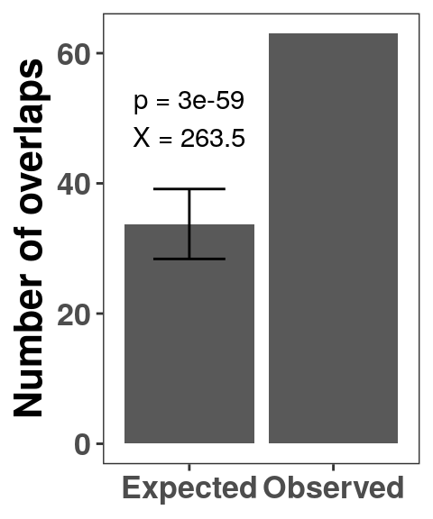

```r
c1 <- data.frame(
  meanz = mean(s3c.rands),
  sdev = sd(s3c.rands),
  mup = mean(s3c.rands) + sd(s3c.rands),
  mdown = mean(s3c.rands) - sd(s3c.rands),
  type = c("Expected")
) %>%
  add_case(type = "Observed", meanz = 63, sdev = NA, mup = NA, mdown = NA) %>%
  ggplot(., aes(x = type, y = meanz, ymin = mdown, ymax = mup))+
  geom_col()+
  geom_errorbar(width = .5)+
  geom_text(inherit.aes = FALSE, data = c.res1, aes(x = "Expected", y = 50, label = labz))+
  labs(x = NULL,
       y = "Number of overlaps")+
  theme_bw()+
  theme(panel.grid = element_blank(),
        text = element_text(size = ts, face = "bold"))

c1
```

```r
ggsave(plot = c1, filename = "../figures/chi_spaac_dspaac.png", width = 2.5, height = 3)
```

##### figure 3d

```r
# this is how many genes are significant in each category
f3d.vals <- fc.plot.df2 %>%
    filter(sig == TRUE & comp %in% c("D-SPAAC seq (WT)", "D-SPAAC seq (xrn1 H41A)")) %>%
    split(.$comp, drop = TRUE) %>%
    map(.f = nrow)

# Essentially asking, if I pick the same number of significant genes from each
# category, how many overlaps do we get compared to how many we actually got?
s3d.rands <- lapply(1:1e4, function(x) {
  # randomly sample a number of genes from D-SPAAC WT
  ds.genes <- fc.plot.df2 %>%
    filter(comp == "D-SPAAC seq (WT)") %>%
    pull(target_id) %>%
    sample(., size = f3d.vals$`D-SPAAC seq (WT)`, replace = FALSE)

  # randomly sample a number of genes from D-SPAAC XRN1
  s.genes <- fc.plot.df2 %>%
    filter(comp == "D-SPAAC seq (xrn1 H41A)") %>%
    pull(target_id) %>%
    sample(., size = f3d.vals$`D-SPAAC seq (xrn1 H41A)`, replace = FALSE)

  # calculate overlap
  intersect(ds.genes, s.genes) %>%
    length()
}) %>%
  unlist()
```

A chi squared test will take a contingency table that looks like this

```r
ct2 <- fc.plot.df2 %>%
  filter(comp %in% c("D-SPAAC seq (WT)", "D-SPAAC seq (xrn1 H41A)")) %>%
  group_by(sig, comp) %>%
  tally() %>%
  ungroup() %>%
  pivot_wider(names_from = sig, values_from = n) %>%
  column_to_rownames("comp")

c.res2 <- chisq.test(ct2) %>%
  broom::tidy() %>%
  mutate(p.value = signif(p.value, 3),
         statistic = signif(statistic, 4),
         labz = paste0("p = ", p.value, "\nX = ", statistic))
```

A graph of the above

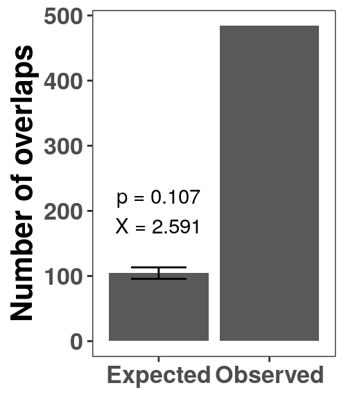

```r
c2 <- data.frame(
  meanz = mean(s3d.rands),
  sdev = sd(s3d.rands),
  mup = mean(s3d.rands) + sd(s3d.rands),
  mdown = mean(s3d.rands) - sd(s3d.rands),
  type = c("Expected")
) %>%
  add_case(type = "Observed", meanz = 484, sdev = NA, mup = NA, mdown = NA) %>%
  ggplot(., aes(x = type, y = meanz, ymin = mdown, ymax = mup))+
  geom_col()+
  geom_errorbar(width = .5)+
  labs(x = NULL,
       y = "Number of overlaps")+
  theme_bw()+
  theme(panel.grid = element_blank(),
        text = element_text(size = ts, face = "bold"))+
  geom_text(inherit.aes = FALSE, data = c.res2, aes(x = "Expected", y = 200, label = labz))

c2
```

```r
ggsave(plot = c2, filename = "../figures/chi_wt_xrn1.png", width = 2.6, height = 3)
```

### GO results

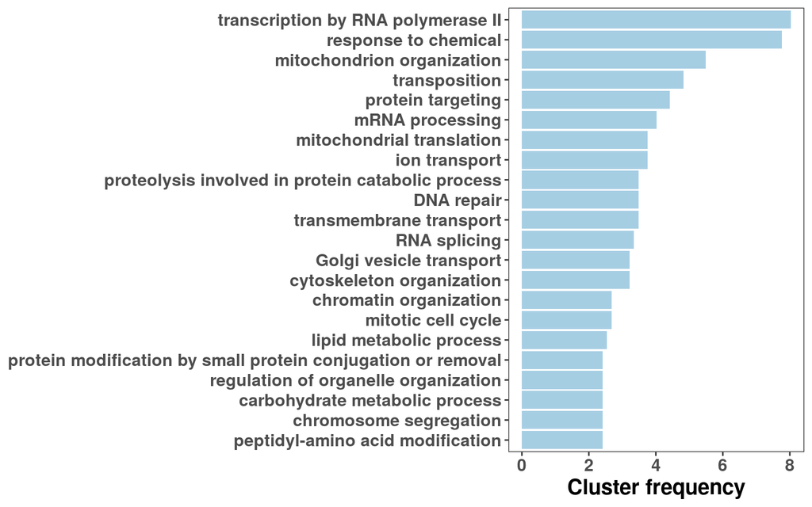

```r
df <- read_tsv("../data_frames/dspaac_go.tsv") %>%
  mutate(CLUSTER_FREQUENCY = str_remove(CLUSTER_FREQUENCY, "\\%") %>% as.numeric()) %>%
  arrange(desc(CLUSTER_FREQUENCY)) %>%
  filter(CLUSTER_FREQUENCY >= 2.4)

cat.order <- df %>%
  arrange(CLUSTER_FREQUENCY) %>%
  pull(TERM)

go1 <- df %>%
  ggplot(., aes(CLUSTER_FREQUENCY, factor(TERM, cat.order)))+
  geom_col(fill = "#A6CEE3")+
  labs(x = "Cluster frequency",
       y = NULL)+
  theme_bw()+
  theme(panel.grid = element_blank(),
        text = element_text(size = 15, face = "bold"))

ggsave(plot = go1, filename = "../figures/dspaac_spaac_inc_cats.png", width = 8, height = 5)

go1
```

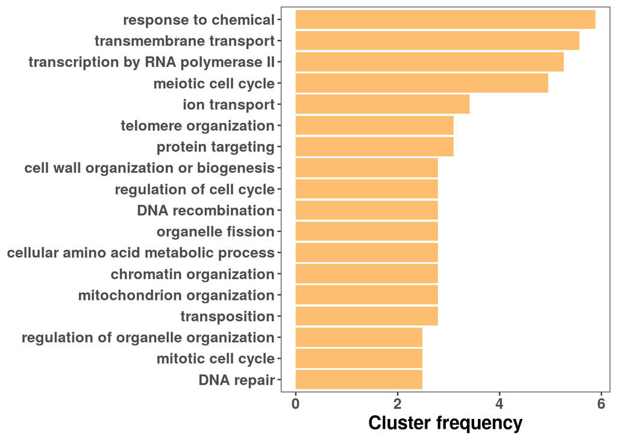

```r
df2 <- read_tsv("../data_frames/mut_go.tsv") %>%
  mutate(CLUSTER_FREQUENCY = str_remove(CLUSTER_FREQUENCY, "\\%") %>% as.numeric()) %>%
  arrange(desc(CLUSTER_FREQUENCY)) %>%
  filter(CLUSTER_FREQUENCY >= 2.4)

cat.order <- df2 %>%
  arrange(CLUSTER_FREQUENCY) %>%
  pull(TERM)

go2 <- df2 %>%
  ggplot(., aes(CLUSTER_FREQUENCY, factor(TERM, cat.order)))+
  geom_col(fill = "#FDBF6F")+
  labs(x = "Cluster frequency",
       y = NULL)+
  theme_bw()+
  theme(panel.grid = element_blank(),
        text = element_text(size = 15, face = "bold"))

go2
```

```r
ggsave(plot = go2, filename = "../figures/mut_cats.png", width = 8, height = 5)
```

all volcanoes

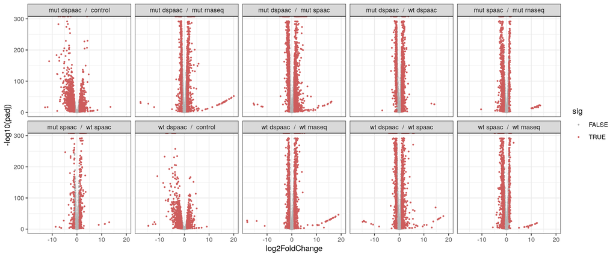

```r
dsdf %>%
    mutate(
      sig = ifelse(abs(log2FoldChange) >= fccut & padj <= qcut, TRUE, FALSE),
      sig = ifelse(is.na(sig), FALSE, sig),
      comparison = str_replace_all(comparison, "_", " ") %>% str_replace("over", " / ")
    ) %>%
  arrange(sig) %>%
  ggplot(., aes(log2FoldChange, -log10(padj), color = sig))+
  geom_point(size = .5)+
  facet_wrap(~comparison, ncol = 5)+
  scale_color_manual(values = c("grey70", "indianred"))+
  theme_bw()
```

```r
ggsave(plot = last_plot(), filename = "../figures/all_volcanoes.png", width = 12, height = 5)
```